# Demonstration of the system

## Code Preperation

### Importing libraries and dependencies for Tensorflow

```python
import tensorflow as tf
from tensorflow.keras import layers
import os
import sys
import platform
```

[output not shown]

### Verify Python, TensorFlow and Keras Installation

```python
print(f"Python Platform: {platform.platform()}")
print(f"Tensor Flow Version: {tf.__version__}")
print(f"Keras Version: {tf.keras.__version__}")
print()
print(f"Python {sys.version}")
```

```
Python Platform: Linux-5.15.79.1-microsoft-standard-WSL2-x86_64-with-glibc2.35
Tensor Flow Version: 2.11.0
Keras Version: 2.11.0

Python 3.9.15 (main, Nov 24 2022, 14:31:59)
[GCC 11.2.0]
```

### Set warning level at "INFO"

```python
tf.get_logger().setLevel('INFO')

#os.environ['TF_CPP_MIN_LOG_LEVEL'] = '3'  # or any {'0', '1', '2'}
```

### Importing libraries and dependencies for ANN

```python
import numpy as np
from keras.applications.vgg19 import VGG19
from keras.applications.vgg16 import VGG16
import keras
from keras.layers import Input, Flatten, Dense
from keras.models import Model
import sys
import os

import matplotlib.pyplot as plt
import matplotlib as mpl


def escape():
    sys.exit()
```

## Pre-processing Dataset

### Import Dataset

```python
import_directory = "/mnt/c/SPECTRE/Dataset/ISCX-2012/Processed/"
counter = 0
data_array = np.empty((0, 2))
files = os.listdir(import_directory)
for file in files:
    print('Opening File : ', file)
    data_set = np.load(import_directory+file,allow_pickle=True)
    data_array = np.vstack((data_array, data_set))

#separated = np.array([x for x in data_array if x[1] == 0])
```

```
Opening File :  destinationPayload_TestbedMonJun14Flows.xml.npy
Opening File :  destinationPayload_TestbedSatJun12Flows.xml.npy
Opening File :  destinationPayload_TestbedSunJun13Flows.xml.npy
Opening File :  destinationPayload_TestbedThuJun17-2Flows.xml.npy
Opening File :  destinationPayload_TestbedThuJun17-3Flows.xml.npy
Opening File :  destinationPayload_TestbedTueJun15-1Flows.xml.npy
Opening File :  destinationPayload_TestbedTueJun15-2Flows.xml.npy
Opening File :  destinationPayload_TestbedTueJun15-3Flows.xml.npy
Opening File :  destinationPayload_TestbedWedJun16-1Flows.xml.npy
Opening File :  destinationPayload_TestbedWedJun16-2Flows.xml.npy
Opening File :  destinationPayload_TestbedWedJun16-3Flows.xml.npy
```

```python
#np.random.shuffle(separated)
np.random.shuffle(data_array)
print("ok")
```

```
ok
```

### Splitting an input array of images (data_array) into two sets: training and test sets.

- Define the number of rows and columns of the images
- Split the input array of images into training and test sets with the defined percentage ( 75% training 25% testing)
- Extract the images for the training set and testing set
- Reshape the images in training and testing sets to have specific dimension (img_row, img_col, 3)

```python
img_row = 50
img_col = 50

N = np.shape(data_array)[0]
train_test_split_percentage = 0.75

X_train = data_array[:int(N * train_test_split_percentage), 0]
X_test = data_array[int(N * train_test_split_percentage):, 0]

X_train = np.array([x.reshape(img_row, img_col, 3) for x in X_train])
X_test = np.array([x.reshape(img_row, img_col, 3) for x in X_test])
```

### Splitting a dataset into two parts, one for training and one for testing.

- Creating two arrays: y_train and y_test, and the source of data is data_array.
- It's slicing the data_array into two parts:
  1. y_train is created by getting the first part of the data_array up until the train_test_split_percentage * total number of data_array's rows.
  2. y_test is created by getting the rest of the data_array, starting from the last element of the y_train.

Then the code wraps each element in y_train and y_test with an additional set of square brackets using np.array([[x] for x in y_train]) and np.array([[x] for x in y_test]) respectively, this will create arrays of shape (x,1) with x being the number of elements in the original y_train or y_test.

- Create arrays of shape (x,1) with x being the number of elements in the original y_train or y_test.

```python
y_train = data_array[:int(N * train_test_split_percentage), 1]
y_test = data_array[int(N * train_test_split_percentage):, 1]

y_train = np.array([[x] for x in y_train])
y_test = np.array([[x] for x in y_test])
```

## Starting ANN Training

### Creating an instance of the VGG19 model

- A VGG19 model is being created and assigned to the variable "model_vgg19_conv"
- The model is set to not include the final "top" layers (the fully connected layers at the end of the model)
- The model will use pre-trained weights from the "imagenet" dataset
- The model's input shape is set to the dimensions of the input image (img_col and img_row) and the number of color channels (3 for RGB)

```python
model_vgg19_conv = VGG19(include_top=False, weights='imagenet', input_shape=(img_col, img_row, 3))
```

[output not shown]

### Plotting image for training

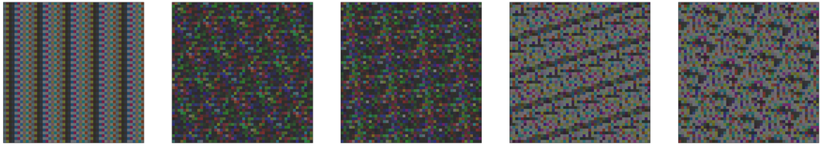

```python
#ploting images for data
%matplotlib inline
n = 40  # how many digits we will display
plt.figure(figsize=(400, 150))
for i in range(6,11):
    # display original
    ax = plt.subplot(1, n, i + 1)
    plt.imshow(X_train[i])
    plt.gray()
    ax.get_xaxis().set_visible(False)
    ax.get_yaxis().set_visible(False)
plt.show()
plt.close()
```

### Preparing `vgg19 model`

- The training is disabled by setting "layer.trainable = False"
- The name of the layer is printed with "print(layer.name)"
- The code is disabling the training for all the layers of the model, so that the model can be used as a pretrained model and will not learn or change its weights.

```python
for layer in model_vgg19_conv.layers:
    layer.trainable = False
    print(layer.name)
```

```
input_1
block1_conv1
block1_conv2
block1_pool
block2_conv1
block2_conv2
block2_pool
block3_conv1
block3_conv2
block3_conv3
block3_conv4
block3_pool
block4_conv1
block4_conv2
block4_conv3
block4_conv4
block4_pool
block5_conv1
block5_conv2
block5_conv3
block5_conv4
block5_pool
```

### Creating new model based on `vgg19`

- Modifying a pre-existing model, "model_vgg19_conv," to create a new model, "my_model."
- The code first assigns the output of the pre-existing model, "model_vgg19_conv," to the variable "x"; Then it flattens the output using "x = layers.Flatten()(x)".
- It then uses a dense layer of 128 neurons and uses the "relu" activation function to process the output. This is assigned to the same variable "x".
- The next line adds another dense layer with 1 neuron and using the activation function "sigmoid". It assigns the same variable "x" and giving it a name 'predictions'
- Then the code creates a new model, "my_model," using the inputs from the pre-existing model and the outputs from the new layers added to the variable "x".
- The last line "my_model.summary()" prints a summary of the new model created.

In simple terms, the code is modifying the pre-existing model to classify images based on their contents by adding layers to it and creating a new model to do so.

```python
x = model_vgg19_conv.output
x = layers.Flatten()(x)
x = layers.Dense(128, activation='relu')(x)
x = layers.Dense(1, activation='sigmoid', name='predictions')(x)
my_model = tf.keras.Model(inputs=model_vgg19_conv.input, outputs=x)
my_model.summary()
```

```
Model: "model"
_________________________________________________________________
 Layer (type)                Output Shape              Param #
=================================================================
 input_1 (InputLayer)        [(None, 50, 50, 3)]       0

 block1_conv1 (Conv2D)       (None, 50, 50, 64)        1792

 block1_conv2 (Conv2D)       (None, 50, 50, 64)        36928

 block1_pool (MaxPooling2D)  (None, 25, 25, 64)        0

 block2_conv1 (Conv2D)       (None, 25, 25, 128)       73856

 block2_conv2 (Conv2D)       (None, 25, 25, 128)       147584

 block2_pool (MaxPooling2D)  (None, 12, 12, 128)       0

 block3_conv1 (Conv2D)       (None, 12, 12, 256)       295168

 block3_conv2 (Conv2D)       (None, 12, 12, 256)       590080

 block3_conv3 (Conv2D)       (None, 12, 12, 256)       590080

 block3_conv4 (Conv2D)       (None, 12, 12, 256)       590080

 block3_pool (MaxPooling2D)  (None, 6, 6, 256)         0

 block4_conv1 (Conv2D)       (None, 6, 6, 512)         1180160

 block4_conv2 (Conv2D)       (None, 6, 6, 512)         2359808

 block4_conv3 (Conv2D)       (None, 6, 6, 512)         2359808

 block4_conv4 (Conv2D)       (None, 6, 6, 512)         2359808

 block4_pool (MaxPooling2D)  (None, 3, 3, 512)         0

 block5_conv1 (Conv2D)       (None, 3, 3, 512)         2359808

 block5_conv2 (Conv2D)       (None, 3, 3, 512)         2359808

 block5_conv3 (Conv2D)       (None, 3, 3, 512)         2359808

 block5_conv4 (Conv2D)       (None, 3, 3, 512)         2359808

 block5_pool (MaxPooling2D)  (None, 1, 1, 512)         0

 flatten (Flatten)           (None, 512)               0

 dense (Dense)               (None, 128)               65664

 predictions (Dense)         (None, 1)                 129

=================================================================
Total params: 20,090,177
Trainable params: 65,793
Non-trainable params: 20,024,384
_________________________________________________________________
```

### Configuring the new model

- The first line, "my_model.compile," sets up the training process for the model by defining the loss function, optimization algorithm, and metrics to be used.
  - The "loss" parameter is set to "keras.losses.binary_crossentropy" which is a loss function used for binary classification problems, where the output can be either 0 or 1.
  - The "optimizer" parameter is set to "keras.optimizers.RMSprop()" which is an optimization algorithm used to update the model's weights during training.
  - The "metrics" parameter is set to "accuracy" which is used to evaluate the model's performance during training.
- The next two lines set the batch size and number of epochs for the training process.
  - The "batch_size" variable is set to 32, meaning that the model will process 32 images at a time before updating its weights.
  - The "epochs" variable is set to 2, meaning that the model will be trained on the entire dataset 2 times.

In simple terms, this code is setting up the training process for the model by defining how the model should be optimized during training and how the performance will be evaluated. It also sets the number of images that the model should process before updating its weights and the number of times that the model should see the entire data set.

```python
my_model.compile(loss=keras.losses.binary_crossentropy,
              optimizer=keras.optimizers.RMSprop(),
              metrics=['accuracy'])

batch_size = 32
epochs = 2
```

## Training the model

The "my_model.fit" function trains the model on the input data set, "X_train," and the corresponding labels, "y_train."

It takes several parameters to configure the training process:

- The "batch_size" parameter is set to the value of the variable "batch_size" which is set at 32. The model will process 32 images at a time before updating its weights.
- The "epochs" parameter is set to the value of the variable "epochs" which was define as 2. This means that the model will be trained on the entire dataset 2 times.
- The "verbose" parameter is set to 1, which means that the training progress will be displayed on the console while the model is being trained.
- The "validation_split" parameter is set to 0.2, which means that 20% of the training data will be used as validation data to evaluate the model's performance during training.

```python
hist = my_model.fit(X_train, y_train,
          batch_size=batch_size,
          epochs=epochs,
          verbose=1,
          validation_split=0.2)
```

```
2023-01-01 02:53:31.371931: W tensorflow/tsl/framework/cpu_allocator_impl.cc:82] Allocation of 3612570000 exceeds 10% of free system memory.
```

```
2023-01-01 02:53:42.103254: W tensorflow/tsl/framework/cpu_allocator_impl.cc:82] Allocation of 20480000 exceeds 10% of free system memory.
2023-01-01 02:53:42.124313: W tensorflow/tsl/framework/cpu_allocator_impl.cc:82] Allocation of 20480000 exceeds 10% of free system memory.
2023-01-01 02:53:42.278811: W tensorflow/tsl/framework/cpu_allocator_impl.cc:82] Allocation of 20480000 exceeds 10% of free system memory.
```

### Evaluating the performance of the trained model

- The "my_model.evaluate" function takes two inputs, the test data, "X_test," and the corresponding labels, "y_test."
- The "verbose" parameter, which is set to 0 in this case. When "verbose" is set to 0, the function runs silently and does not print any output to the console.
- The function returns the value of the loss function and any additional metrics that were specified during the model's compilation. This value is then assigned to the variable "score."

```python
score = my_model.evaluate(X_test, y_test, verbose=0)
```

### Printing the test loss and test accuracy of the trained model

- The first line, "print('Test loss:', score[0])," prints the value of the test loss, which is stored in the first element of the "score" variable.
- The second line, "print('Test accuracy:', score[1])," prints the value of the test accuracy, which is stored in the second element of the "score" variable.

```python
print('Test loss:', score[0])
print('Test accuracy:', score[1])
```

```
Test loss: 0.033859364688396454
Test accuracy: 0.9909067749977112
```